# WB-PD-2

```python
from PIL import Image
import numpy as np
import scipy
from scipy import ndimage
from matplotlib import cm
from numpy import zeros
import time
```

## Wgrywanie grafiki do testowania

[figure not shown]

[figure not shown]

```python
image = Image.open("red_barron.jpg")
display(image)
image_gray = image.convert('L')
display(image_gray)
```

## Ustawianie filtrów do konwolucji

Do implementacji kilku filtrów konwolucji użyłem kilku przykładowych ze strony : https://en.wikipedia.org/wiki/Kernel_(image_processing)

Macierze, których funkcją jest przekształcenie obrazu, są nazwane analogicznie do ich działania.

```python
Edge_detection = [
        [-1,-1,-1],
        [-1,8,-1],
        [-1,-1,-1]
]
Edge_detection_2 = [
    [1,0,-1],
    [0,0,0],
    [-1,0,1]
]
Sharpen = [
    [0,-1,0],
    [-1,5,-1],
    [0,-1,0]
]
Gaussian_blur = [
    [1/16,2/16,1/16],
    [2/16,4/16,2/16],
    [1/16,2/16,1/16]
]
Emboss = [
    [-2,-1,0],
    [-1,1,1],
    [0,1,2]
]
```

## Konwolucja z użyciem pętli

Zacznijmy z zdefiniowaniem funkcji konwolucji z użyciem pętli.

```python
def conv_one_step(image,kernel,stride=1):
    #dla szarości
    if(len(np.asarray(image).shape) == 2):
        H_img = image.size[1]
        W_img = image.size[0]
        H_ker = len(kernel)
        W_ker = len(kernel[0])

        h = H_ker//2
        w = W_ker//2
        image_out = np.reshape(np.zeros(image.size),(H_img,W_img))
        image = np.asarray(image)
        for i in range(h,H_img-h,stride):
            for j in range(w,W_img-w,stride):
                sum = 0
                for m in range(H_ker):
                    for n in range(W_ker):
                        sum = sum + kernel[m][n]*image[i-h+m][j-w+n]
                image_out[i][j] = sum
        image_out = Image.fromarray(np.uint8(image_out)).convert('RGB')
        return image_out
    #dla rgb
    if(len(np.asarray(image).shape) == 3):
        H_img = image.size[1]
        W_img = image.size[0]
        H_ker = len(kernel)
        W_ker = len(kernel[0])

        h = H_ker//2
        w = W_ker//2
        image_out_r = np.reshape(np.zeros(image.size),(H_img,W_img))
        image_out_g = np.reshape(np.zeros(image.size),(H_img,W_img))
        image_out_b = np.reshape(np.zeros(image.size),(H_img,W_img))
        image_r = np.asarray(image)[:,:,0]
        image_g = np.asarray(image)[:,:,1]
        image_b = np.asarray(image)[:,:,2]
        for i in range(h,H_img-h,stride):
            for j in range(w,W_img-w,stride):
                sum_r = 0
                sum_g = 0
                sum_b = 0
                for m in range(H_ker):
                    for n in range(W_ker):
                        sum_r = sum_r + kernel[m][n]*image_r[i-h+m][j-w+n]
                        sum_g = sum_g + kernel[m][n]*image_g[i-h+m][j-w+n]
                        sum_b = sum_b + kernel[m][n]*image_b[i-h+m][j-w+n]
                image_out_r[i][j] = sum_r
                image_out_g[i][j] = sum_g
                image_out_b[i][j] = sum_b
        image_out = (np.dstack((image_out_r,image_out_g,image_out_b))).astype(np.uint8)
        image_out = Image.fromarray(np.uint8(image_out))
        return image_out
    #dla wielu filtrów
    def conv(image,kernels,stride = 1):
        images = []
        for kernel in kernels:
            images.append(conv_one_step(image,kernel,stride=1))
        return images
```

## Testowanie funkcji

Porównam teraz obrazy wyjściowe przetworzone przez moją funkcję oraz przez funkcję konwolucyjną wbudowaną z pakietu scipy.

```python
image_2 = conv_one_step(image_gray,Sharpen,1)
image_2_function = ndimage.convolve(image_gray,Sharpen)
```

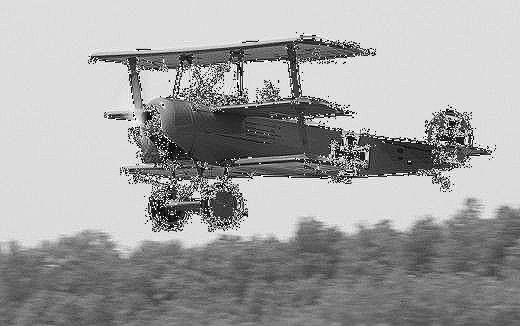

```python
#Obraz z wbudowanej funkcji z użyciem filrtu Sharpen
Image.fromarray(np.uint8(image_2_function))
```

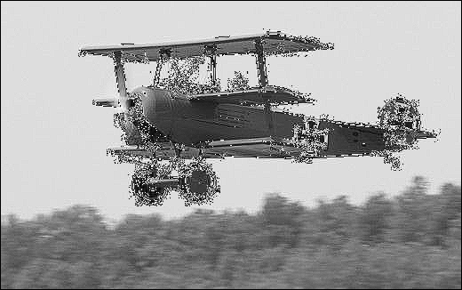

```python
#Obraz uzyskany z zaimplementowanej funkcji
image_2
```

```python
image_3 = conv_one_step(image_gray,Edge_detection,1)
image_3_function = ndimage.convolve(image_gray,Edge_detection)
```

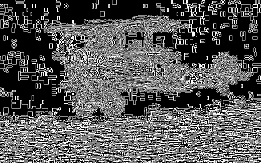

```python
#Teraz porównajmy działanie dla innego filtra, Edge_detection
#Dla wbudowanej funkcji
Image.fromarray(np.uint8(image_3_function))
```

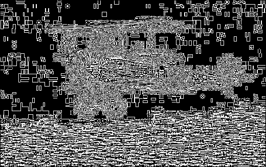

```python
#Nasza funkcja
image_3
```

[figure not shown]

```python
#Dla rgb
image_4 = conv_one_step(image,Gaussian_blur,1)
image_4
```

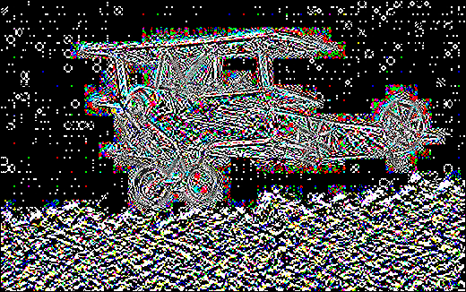

```python
#Inne filtry dla rgb
conv_one_step(image,Edge_detection_2)
```

### Wnioski przy użyciu konwolucji z pętlą

Jak widzimy, wytworzone obrazy są identyczne dla obydwu funkcji.

## Implementacja dla mnożenia macierzowego

Zaimplementowaliśmy już konwolucję pętlową, zabierzmy się teraz za metodę mnożenia macierzy.

W tym punkcie muszę dać kredyt poszczególnym stroną za zaopatrzenie mnie w teorię i informacje o tego typu konwolucji:https://wiseodd.github.io/techblog/2016/07/16/convnet-conv-layer/,

https://medium.com/analytics-vidhya/implementing-convolution-without-for-loops-in-numpy-ce111322a7cd

Również muszę przyznać się, iż podana strona pomogła mi z kodem, iż początkowo nie miałem pomysłu na jego napisanie: https://titanwolf.org/Network/Articles/Article?AID=50350878-b76c-4b5c-b0ac-d4da5fdcf1fb#gsc.tab=0

```python
def im2col(image, kernel):
    H_img = image.shape [0] - kernel[0] + 1
    W_img = image.shape [1] - kernel[1] + 1
    img_out = np.zeros([H_img * W_img,kernel[0] * kernel[1]])
    for i in range (H_img):
        for j in range (W_img):
            img_out[i*W_img + j,:] = image[i: i + kernel[0] , j: j + kernel[1]].ravel(order = 'F')
    return img_out

def conv_matrix_one_step(image, kernel):
    #tylko dla szarości
    h_kernel = kernel.shape[0]
    w_kernel = kernel.shape[1]
    h_image = image.shape[0]
    w_image = image.shape[1]
    h_out = h_image - h_kernel + 1
    w_out = w_image - w_kernel + 1


    h_out = int(h_out)
    w_out = int(w_out)

    image_processed = im2col(image,kernel.shape)
    kernel_flat = kernel.flatten()
    img_out = image_processed @ kernel_flat
    img_out = img_out.reshape(h_out,w_out)
    img_out = Image.fromarray(np.uint8(img_out))

    return img_out
def conv_matrix(image,kernels):
    images = []
    for kernel in kernels:
        images.append(conv_matrix_one_step(image,kernel))
    return images
```

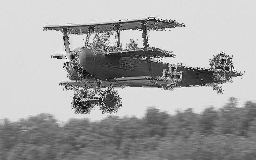

```python
#Użycie konwolucji dla mnożenia macierzowego, z powodów uproszczenia użyłem funkcji dla jednego filtru.
conv_matrix_one_step(np.asarray(image_gray),np.asarray(Sharpen))
```

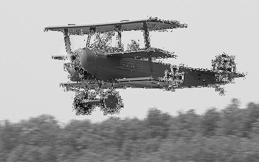

```python
#Użycie funkcji wbudowanej
image_2_function2 = ndimage.convolve(image_gray,Sharpen)
Image.fromarray(np.uint8(image_2_function2))
```

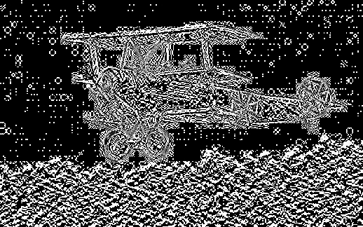

```python
#Druga próbka, dla naszej funkcji
conv_matrix_one_step(np.asarray(image_gray),np.asarray(Edge_detection_2))
```

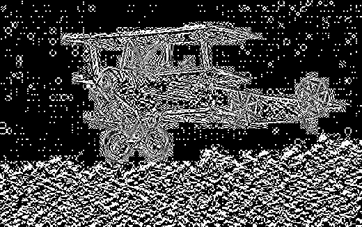

```python
#Drugi przykład dla funkcji wbudowanej
image_3_function3 = ndimage.convolve(image_gray,Edge_detection_2)
Image.fromarray(np.uint8(image_3_function3))
```

Możemy stwierdzić, iż obrazy są identyczne.

## Porównanie czasowe

Przejdźmy do sendna naszej pracy i sprawdźmy obciążenie czasowe dla obydwu funkcji. Zacznijmy z funkcją z pętlą.

```python
start_time = time.time()
conv_one_step(image_gray,Edge_detection_2)
print("Czas potrzebny do wykonania: ", time.time()-start_time)
```

```
Czas potrzebny do wykonania:  6.676887273788452
```

Co w przypadku z obrazem rgb, 'na logikę' wykonanie powinno być trzy razy dłuższe.

```python
#And it almost is
start_time = time.time()
conv_one_step(image,Edge_detection_2)
print("Time taken to fully execute: ", time.time()-start_time)
```

```
Time taken to fully execute:  17.65313959121704
```

Teraz sprawdźmy dla tych samych parametrów dla konwolucji mnożenia macierzowego:

```python
start_time = time.time()
conv_matrix_one_step(np.asarray(image_gray),np.asarray(Edge_detection_2))
print("Time taken to fully execute: ", time.time()-start_time)
```

```
Time taken to fully execute:  0.5236778259277344
```

#### Około 13 razy szybsza!

## Konkluzje

Jak widzimy użycie drugiej metody, tudzież metody mnożenia macierzowego daje około 13 razy lepsze (szybsze) wyniki. Oczywiście moja implementacja pętlowego rozwiązania nie jest najbardziej optymalna z możliwych, lecz złożonościowo jest taka sama, czyli O(n^2). Niemniej jednak, różnica pomiędzy dwoma implementacjami jest znacząco duża, by wyrugować użycie implementacji pętlowej. Wektoryzacja pakietów pythonowych, np. numpy znacznie przyspiesza działanie programu, w przeciwieństwie do używania zakotwiczonych pętli, które zużywają sporą ilość operacji. Co więcej w macierzowej interpretacji nie marnujemy czasu na wymnażanie obiektów znajdujących się poza krawędzią obrazu.

Skalę różnicy można sobie wyobrazić uświadomiwszy sobię złożoność kwadratową dla pętli. Użyta grafika w przykładzie przeze mnie nie była dużych rozmiarów, a i tak metoda pętlowa zajeła 17.66 sekund do wykonania. Przy użyciu większej ilości obrazów oraz obrazów większej rozdzielczości, metoda byłaby niefunkcjonalna.